# Home Submission(week-11)

Divya Reddy

2025-11-12

```r
yrbss <- read.csv("yrbss.csv")
nrow(yrbss)
```

```
## [1] 13583
```

```r
dim(yrbss)      # number of rows and columns
```

```
## [1] 13583    13
```

```r
head(yrbss)     # first few rows
```

```
##   age gender grade hispanic                                      race height
## 1  14 female     9      not                 Black or African American     NA
## 2  14 female     9      not                 Black or African American     NA
## 3  15 female     9 hispanic Native Hawaiian or Other Pacific Islander   1.73
## 4  15 female     9      not                 Black or African American   1.60
## 5  15 female     9      not                 Black or African American   1.50
## 6  15 female     9      not                 Black or African American   1.57
##   weight   helmet_12m text_while_driving_30d physically_active_7d
## 1     NA        never                      0                    4
## 2     NA        never                   <NA>                    2
## 3  84.37        never                     30                    7
## 4  55.79        never                      0                    0
## 5  46.72 did not ride          did not drive                    2
## 6  67.13 did not ride          did not drive                    1
##   hours_tv_per_school_day strength_training_7d school_night_hours_sleep
## 1                      5+                    0                        8
## 2                      5+                    0                        6
## 3                      5+                    0                       <5
## 4                       2                    0                        6
## 5                       3                    1                        9
## 6                      5+                    0                        8
```

```r
names(yrbss)    # list of variable names
```

```
##  [1] "age"                      "gender"
##  [3] "grade"                    "hispanic"
##  [5] "race"                     "height"
##  [7] "weight"                   "helmet_12m"
##  [9] "text_while_driving_30d"   "physically_active_7d"
## [11] "hours_tv_per_school_day"  "strength_training_7d"
## [13] "school_night_hours_sleep"
```

## Part 1: Exploring and Cleaning the Data

```r
yrbss <- read.csv("yrbss.csv")

str(yrbss)
```

```
## 'data.frame':    13583 obs. of  13 variables:
##  $ age                     : int  14 14 15 15 15 15 15 14 15 15 ...
##  $ gender                  : chr  "female" "female" "female" "female" ...
##  $ grade                   : chr  "9" "9" "9" "9" ...
##  $ hispanic                : chr  "not" "not" "hispanic" "not" ...
##  $ race                    : chr  "Black or African American" "Black or African American" "Native Hawaiian or Other Pacific Islander" "Black or African American" ...
##  $ height                  : num  NA NA 1.73 1.6 1.5 1.57 1.65 1.88 1.75 1.37 ...
##  $ weight                  : num  NA NA 84.4 55.8 46.7 ...
##  $ helmet_12m              : chr  "never" "never" "never" "never" ...
##  $ text_while_driving_30d  : chr  "0" NA "30" "0" ...
##  $ physically_active_7d    : int  4 2 7 0 2 1 4 4 5 0 ...
##  $ hours_tv_per_school_day : chr  "5+" "5+" "5+" "2" ...
##  $ strength_training_7d    : int  0 0 0 0 1 0 2 0 3 0 ...
##  $ school_night_hours_sleep: chr  "8" "6" "<5" "6" ...
```

```r
summary(yrbss)
```

```
##       age           gender             grade             hispanic
##  Min.   :12.00   Length:13583       Length:13583       Length:13583
##  1st Qu.:15.00   Class :character   Class :character   Class :character
##  Median :16.00   Mode  :character   Mode  :character   Mode  :character
##  Mean   :16.16
##  3rd Qu.:17.00
##  Max.   :18.00
##  NA's   :77
##      race               height          weight        helmet_12m
##  Length:13583       Min.   :1.270   Min.   : 29.94   Length:13583
##  Class :character   1st Qu.:1.600   1st Qu.: 56.25   Class :character
##  Mode  :character   Median :1.680   Median : 64.41   Mode  :character
##                     Mean   :1.691   Mean   : 67.91
##                     3rd Qu.:1.780   3rd Qu.: 76.20
##                     Max.   :2.110   Max.   :180.99
##                     NA's   :1004    NA's   :1004
##  text_while_driving_30d physically_active_7d hours_tv_per_school_day
##  Length:13583           Min.   :0.000        Length:13583
##  Class :character       1st Qu.:2.000        Class :character
##  Mode  :character       Median :4.000        Mode  :character
##                         Mean   :3.903
##                         3rd Qu.:7.000
##                         Max.   :7.000
##                         NA's   :273
##  strength_training_7d school_night_hours_sleep
##  Min.   :0.00         Length:13583
##  1st Qu.:0.00         Class :character
##  Median :3.00         Mode  :character
##  Mean   :2.95
##  3rd Qu.:5.00
##  Max.   :7.00
##  NA's   :1176
```

```r
# Check missing values in key columns
colSums(is.na(yrbss[, c("grade", "helmet_12m", "physically_active_7d", "weight")]))
```

```
##                grade           helmet_12m physically_active_7d
##                   79                  311                  273
##               weight
##                 1004
```

```r
# Remove rows with missing data in key variables
yrbss_clean <- yrbss[complete.cases(yrbss[, c("grade", "helmet_12m", "physically_active_7d", "weight")]), ]

# Check new dataset size
nrow(yrbss_clean)
```

```
## [1] 12185
```

```r
# Interpretation: The original YRBSS dataset contained 13,583 observations. After removing rows with missing values in key variables (grade, helmet_12m, physically_active_7d, and weight), 1,398 incomplete rows were removed, leaving 12,185 complete cases. Most missing data were found in the weight variable, followed by helmet_12m and physically_active_7d. The cleaned dataset now contains only complete responses, suitable for reliable analysis.
```

## Part 2: Is Helmet Usage Independent of Grade?

```r
unique(yrbss_clean$helmet_12m)
```

```
## [1] "never"        "did not ride" "sometimes"    "always"       "rarely"
## [6] "most of time"
```

```r
unique(yrbss_clean$grade)
```

```
## [1] "9"     "10"    "12"    "11"    "other"
```

```r
# Remove irrelevant categories
yrbss_clean2 <- subset(
  yrbss_clean,
  helmet_12m != "did not ride" & grade != "other"
)

# Check new unique values
unique(yrbss_clean2$helmet_12m)
```

```
## [1] "never"        "sometimes"    "always"       "rarely"       "most of time"
```

```r
unique(yrbss_clean2$grade)
```

```
## [1] "9"  "10" "12" "11"
```

```r
# Check new number of rows
nrow(yrbss_clean2)
```

```
## [1] 7998
```

```r
# Frequency table
helmet_grade_table <- table(yrbss_clean2$grade, yrbss_clean2$helmet_12m)
helmet_grade_table
```

```
##
##      always most of time never rarely sometimes
##   10     89           70  1533    181        76
##   11     78           63  1501    138        50
##   12     89           65  1549    134        70
##   9      97           72  1838    191       114
```

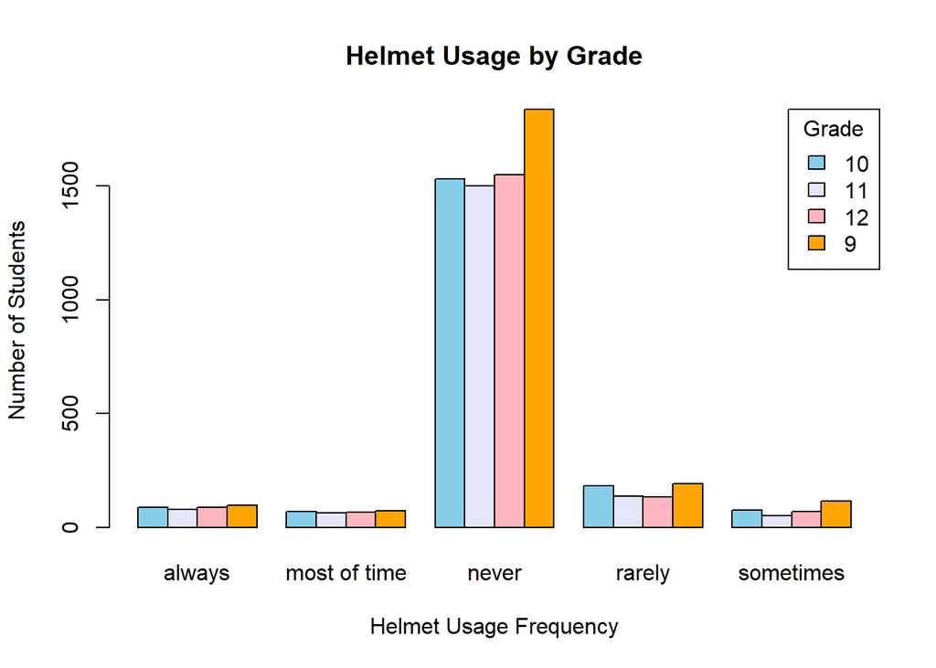

```r
# Grouped bar plot
barplot(
  helmet_grade_table,
  beside = TRUE,
  col = c("skyblue", "lavender", "lightpink", "orange"),
  legend.text = TRUE,
  args.legend = list(title = "Grade", x = "topright"),
  main = "Helmet Usage by Grade",
  xlab = "Helmet Usage Frequency",
  ylab = "Number of Students"
)
```

```r
# Interpretation: The bar plot indicates that helmet usage differs across grades. While most students in all grades reported never wearing a helmet, 9th graders show higher counts in every helmet-use category, suggesting they are generally more active riders. The variation in bar heights across grades suggests a possible association between grade level and helmet usage, meaning helmet-wearing behavior may not be uniform across grades.
```

Research questions

**“Do students in different grades show different patterns of helmet use while riding a bicycle?”**

From the bar plot it indicates that helmet usage differs across grades. While most students in all grades reported never wearing a helmet, 9th graders show higher counts in every helmet-use category, suggesting they are generally more active riders. The variation in bar heights across grades suggests a possible association between grade level and helmet usage, meaning helmet-wearing behavior may not be uniform across grades.

**State the hypotheses for the statistical test you will conduct.**

Hypotheses for the Chi-Square Test of Independence:

- Null Hypothesis (H₀): Helmet usage is independent of grade level.
- Alternative Hypothesis (H₁): Helmet usage is dependent on grade level.

**Check the assumptions for the test. Proceed with the test only after confirming that the assumptions are met.**

- Variables are Categorical: grade –> categorical ;helmet_12m –> categorical
- Observations are Independent: Each student’s response comes from a different individual.

```r
# Create contingency table
helmet_grade_table <- table(yrbss_clean2$grade, yrbss_clean2$helmet_12m)

# Run chi-square test
chisq_test <- chisq.test(helmet_grade_table)

# View expected counts
chisq_test$expected
```

```
##
##         always most of time    never   rarely sometimes
##   10  86.02113     65.79520 1564.707 156.9337  75.54264
##   11  80.76894     61.77794 1469.171 147.3518  70.93023
##   12  84.16742     64.37734 1530.989 153.5519  73.91473
##   9  102.04251     78.04951 1856.133 186.1625  89.61240
```

Since all expected cell counts are greater than 5, the assumption for the Chi-square test is satisfied.Combined with both variables being categorical and the observations being independent, all assumptions for the Chi-square test of independence are met.

**After running the test, report the test statistic, degrees of freedom, and p-value.**

```r
chisq_test
```

```
##
##  Pearson's Chi-squared test
##
## data:  helmet_grade_table
## X-squared = 23.136, df = 12, p-value = 0.02659
```

- The p-value (0.0266) is less than 0.05, which means the result is statistically significant. Therefore, we reject the null hypothesis (H₀).
- This indicates that helmet usage and grade level are not independent there is a significant association between the two variables.
- This suggests that helmet-wearing behavior differs across grades, indicating that age or school level may play a role in bicycle safety practices.

## Part 3: Do Grades Differ in Physical Activity?

```r
# Keep only rows where grade is 9, 10, 11, or 12
yrbss_pa <- subset(yrbss_clean2, grade %in% c("9", "10", "11", "12"))

unique(yrbss_pa$grade)
```

```
## [1] "9"  "10" "12" "11"
```

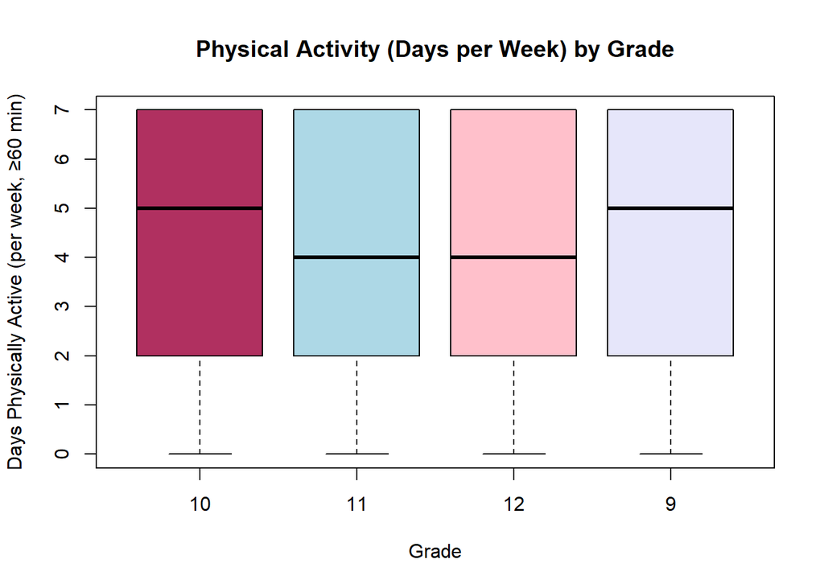

```r
# Boxplot of physical activity by grade
boxplot(
  physically_active_7d ~ grade,
  data = yrbss_pa,
  col = c("maroon", "lightblue", "pink", "lavender"),
  main = "Physical Activity (Days per Week) by Grade",
  xlab = "Grade",
  ylab = "Days Physically Active (per week, ≥60 min)"
)
```

```r
# Interpretation: The boxplot shows that the distribution of physically active days is fairly similar across all grades, though there are slight differences in medians. 9th and 10th graders tend to have a slightly higher median number of active days per week compared to 11th and 12th graders, suggesting a small decline in activity as grade level increases. Overall, the visualization suggests that grade level may be modestly associated with physical activity, with younger students appearing to be more active on average than older students.
```

**“Do students in different grades differ in the number of days they are physically active each week?”**

Based on the boxplot analysis, students in different grades show slightly different levels of physical activity per week. 9th and 10th graders tend to be more physically active, with higher median active days, while 11th and 12th graders report being active on fewer days. This suggests that as students move to higher grades, their weekly physical activity may gradually decrease, possibly due to increased academic demands or lifestyle changes.

**State the hypotheses for the statistical test you will conduct.**

Hypotheses for the Statistical Test (ANOVA):

- Null Hypothesis (H₀): The mean number of physically active days per week is the same across all grade levels.
- Alternative Hypothesis (H₁): The mean number of physically active days per week is not the same across all grade levels.

**Check the assumptions for the test. Proceed with the test only after confirming that the assumptions are reasonably met.**

- The dependent variable is continuous
- The independent variable is categorical
- Independence of observations: Each student’s response is from a different person

```r
# Shapiro-Wilk test for normality by grade
by(yrbss_pa$physically_active_7d, yrbss_pa$grade, shapiro.test)
```

```
## yrbss_pa$grade: 10
##
##  Shapiro-Wilk normality test
##
## data:  dd[x, ]
## W = 0.8735, p-value < 2.2e-16
##
## ------------------------------------------------------------
## yrbss_pa$grade: 11
##
##  Shapiro-Wilk normality test
##
## data:  dd[x, ]
## W = 0.87495, p-value < 2.2e-16
##
## ------------------------------------------------------------
## yrbss_pa$grade: 12
##
##  Shapiro-Wilk normality test
##
## data:  dd[x, ]
## W = 0.88471, p-value < 2.2e-16
##
## ------------------------------------------------------------
## yrbss_pa$grade: 9
##
##  Shapiro-Wilk normality test
##
## data:  dd[x, ]
## W = 0.87187, p-value < 2.2e-16
```

```r
# Test for equal variances
bartlett.test(physically_active_7d ~ grade, data = yrbss_pa)
```

```
##
##  Bartlett test of homogeneity of variances
##
## data:  physically_active_7d by grade
## Bartlett's K-squared = 5.9818, df = 3, p-value = 0.1125
```

```r
# All assumptions are reasonably met: Data are numeric (continuous).Groups are categorical and independent. Variances are equal (p > 0.05). Normality is acceptable given large sample size.
```

**After running the test, report the results, including the test statistic, degrees of freedom, and p-value.**

```r
# Run one-way ANOVA
anova_result <- aov(physically_active_7d ~ grade, data = yrbss_pa)

# View summary
summary(anova_result)
```

```
##               Df Sum Sq Mean Sq F value   Pr(>F)
## grade          3    310  103.34   16.77 7.46e-11 ***
## Residuals   7994  49277    6.16
## ---
## Signif. codes:  0 '***' 0.001 '**' 0.01 '*' 0.05 '.' 0.1 ' ' 1
```

```r
# Interpretation: The ANOVA results show a significant difference in physical activity across grades. This means students in different grades do not have the same average number of active days per week — grade level significantly affects physical activity.
```

**Provide a detailed interpretation of the findings in real-life terms.**

The results show that physical activity levels differ by grade. As students progress through high school, the number of active days per week tends to decrease. 9th and 10th graders are generally more active than 11th and 12th graders. This may be due to academic pressure or lifestyle changes. Promoting regular exercise among older students can help maintain healthy activity habits.

**Explain what the results suggest about differences in physical activity levels across grade levels and discuss what these patterns might imply about student behavior, physical education engagement, or developmental trends.**

The results suggest that physical activity decreases slightly as students move to higher grades. Younger students (grades 9–10) are generally more active, while older students (grades 11–12) show lower activity levels. This pattern may indicate that older students face greater academic demands or reduced participation in physical education and sports. It could also reflect developmental or behavioral changes, such as shifting interests or time constraints. These trends highlight the need to promote continued engagement in physical activity throughout high school to support students’ health and well-being.